# 911-Analysis

## 911 Calls Analysis

we will be analyzing some 911 call data from Kaggle. The data contains the following fields:

```
lat : String variable, Latitude
lng: String variable, Longitude
desc: String variable, Description of the Emergency Call
zip: String variable, Zipcode
title: String variable, Title
timeStamp: String variable, YYYY-MM-DD HH:MM:SS
twp: String variable, Township
addr: String variable, Address
e: String variable, Dummy variable (always 1)
```

Let us go through the notebook and get better insights about the Data.

#### Importing some Usefull libraries for Visualization and EDA

#### Then Load the dataset and start the basic EDA

```python
import pandas as pd
import numpy as np
import matplotlib.pyplot as plt
import seaborn as sns
from pandas_profiling import ProfileReport
```

```python
# Loading the Dataset
df = pd.read_csv("911.csv")
```

```python
# Viewing the head of dataset. How the data looks.
df.head()
```

|  | lat | lng | desc | zip | title | timeStamp | twp | addr | e |
| --- | --- | --- | --- | --- | --- | --- | --- | --- | --- |
| 0 | 40.297876 | -75.581294 | REINDEER CT & DEAD END; NEW HANOVER; Station ... | 19525.0 | EMS: BACK PAINS/INJURY | 2015-12-10 17:10:52 | NEW HANOVER | REINDEER CT & DEAD END | 1 |
| 1 | 40.258061 | -75.264680 | BRIAR PATH & WHITEMARSH LN; HATFIELD TOWNSHIP... | 19446.0 | EMS: DIABETIC EMERGENCY | 2015-12-10 17:29:21 | HATFIELD TOWNSHIP | BRIAR PATH & WHITEMARSH LN | 1 |
| 2 | 40.121182 | -75.351975 | HAWS AVE; NORRISTOWN; 2015-12-10 @ 14:39:21-St... | 19401.0 | Fire: GAS-ODOR/LEAK | 2015-12-10 14:39:21 | NORRISTOWN | HAWS AVE | 1 |
| 3 | 40.116153 | -75.343513 | AIRY ST & SWEDE ST; NORRISTOWN; Station 308A;... | 19401.0 | EMS: CARDIAC EMERGENCY | 2015-12-10 16:47:36 | NORRISTOWN | AIRY ST & SWEDE ST | 1 |
| 4 | 40.251492 | -75.603350 | CHERRYWOOD CT & DEAD END; LOWER POTTSGROVE; S... | NaN | EMS: DIZZINESS | 2015-12-10 16:56:52 | LOWER POTTSGROVE | CHERRYWOOD CT & DEAD END | 1 |

### EDA through pandas-profiling

Instead of just giving you a single output, pandas-profiling enables its user to quickly generate a very broadly structured HTML file containing most of what you might need to know before diving into a more specific and individual data exploration . We will use the insights we get from the output of Pandas Report

#### Please note: It may take some while to run the Pandas Report. Please be patient !

```python
pfr = df.profile_report()
pfr.to_file("/home/ashish/Documents/New Projects/EDA_911.html")
pfr
```

Report generated with pandas-profiling.

### We got a handful of insights from this one line pandas profile report code.

Mentioning few handy insights from EDA :

1. There are 5 categorical variables, 3 Numerical variables and 1 Boolean
2. Column 'e' is rejected as it has only a constant value '1'
3. timeStamp is considered for applying to pd.todatetime() to get days, hours, week etc
4. lat,lng are highly skewed
5. Data has only 72 duplicate rows which is very less compared to size of the data
6. We have 69 Distinct Townships and 159 datapoints are missing in the Township column
7. We have 171 distinct zipcodes and 52129 atapoints are missing in the zip column
8. We have counts for each column in Missing value tab 'Counts'

Let's Proceed with the further analysis on data by visualization using Matplotlib and Seaborn

```python
#Since e has a constant value , dropping the column
df.drop(['e'],axis=1,inplace=True)
```

```python
df.head()
```

|  | lat | lng | desc | zip | title | timeStamp | twp | addr |
| --- | --- | --- | --- | --- | --- | --- | --- | --- |
| 0 | 40.297876 | -75.581294 | REINDEER CT & DEAD END; NEW HANOVER; Station ... | 19525.0 | EMS: BACK PAINS/INJURY | 2015-12-10 17:10:52 | NEW HANOVER | REINDEER CT & DEAD END |
| 1 | 40.258061 | -75.264680 | BRIAR PATH & WHITEMARSH LN; HATFIELD TOWNSHIP... | 19446.0 | EMS: DIABETIC EMERGENCY | 2015-12-10 17:29:21 | HATFIELD TOWNSHIP | BRIAR PATH & WHITEMARSH LN |
| 2 | 40.121182 | -75.351975 | HAWS AVE; NORRISTOWN; 2015-12-10 @ 14:39:21-St... | 19401.0 | Fire: GAS-ODOR/LEAK | 2015-12-10 14:39:21 | NORRISTOWN | HAWS AVE |
| 3 | 40.116153 | -75.343513 | AIRY ST & SWEDE ST; NORRISTOWN; Station 308A;... | 19401.0 | EMS: CARDIAC EMERGENCY | 2015-12-10 16:47:36 | NORRISTOWN | AIRY ST & SWEDE ST |
| 4 | 40.251492 | -75.603350 | CHERRYWOOD CT & DEAD END; LOWER POTTSGROVE; S... | NaN | EMS: DIZZINESS | 2015-12-10 16:56:52 | LOWER POTTSGROVE | CHERRYWOOD CT & DEAD END |

#### Let's convert dayhours with dddd/mm/yy and create new feature with year

##### Create 6 new columns out of timestamp

1. Year
2. Month
3. Day
4. Day_name
5. Date
6. part_of_day

```python
from datetime import datetime
import calendar
```

```python
df['timeStamp'] = df['timeStamp'].apply(lambda x: datetime.strptime(x, "%Y-%m-%d %H:%M:%S"))
```

```python
#Converting to Columns

df['Year'] = df['timeStamp'].apply(lambda t: t.year)
df['Month'] = df['timeStamp'].apply(lambda t: calendar.month_name[t.month])
df['Day'] = df['timeStamp'].apply(lambda t: t.day)
df['day name'] = df['timeStamp'].apply(lambda t: calendar.day_name[t.dayofweek])
df['Date'] = df['timeStamp'].apply(lambda t: t.date())
```

```python
# Since we have different annotations for different time of a day,
# So to get each part of day from Hours we define a function
def partofday(hour):
    return (
        "morning" if 5 <= hour <= 11
        else
        "afternoon" if 12 <= hour <= 17
        else
        "evening" if 18 <= hour <= 22
        else
        "night"
    )
```

```python
# Getting the part of day column
df["part_of_day"] = df['timeStamp'].apply(lambda t: partofday(t.hour))
```

##### We can see that title column has reasons for 911 calls mostly headed as three different type (EMS,Fire,Traffic)

So we will be splitting the title column into Main Reason Column and its subcategories and then drop the title column as it will not be needed further

```python
df['Reason'] = df['title'].apply(lambda title: title.split(':')[0])
df['Reason_subtype'] = df['title'].apply(lambda title: title.split(':')[1])
```

```python
#Since title column is not needed anymore,hence dropping the column
df.drop(['title'],axis=1,inplace=True)

#view the data head now after subsequent changes made above
df.head()
```

|  | lat | lng | desc | zip | timeStamp | twp | addr | Year | Month | Day | day name | Date | part_of_day | Reason | Reason_subtype |
| --- | --- | --- | --- | --- | --- | --- | --- | --- | --- | --- | --- | --- | --- | --- | --- |
| 0 | 40.297876 | -75.581294 | REINDEER CT & DEAD END; NEW HANOVER; Station ... | 19525.0 | 2015-12-10 17:10:52 | NEW HANOVER | REINDEER CT & DEAD END | 2015 | December | 10 | Thursday | 2015-12-10 | afternoon | EMS | BACK PAINS/INJURY |
| 1 | 40.258061 | -75.264680 | BRIAR PATH & WHITEMARSH LN; HATFIELD TOWNSHIP... | 19446.0 | 2015-12-10 17:29:21 | HATFIELD TOWNSHIP | BRIAR PATH & WHITEMARSH LN | 2015 | December | 10 | Thursday | 2015-12-10 | afternoon | EMS | DIABETIC EMERGENCY |
| 2 | 40.121182 | -75.351975 | HAWS AVE; NORRISTOWN; 2015-12-10 @ 14:39:21-St... | 19401.0 | 2015-12-10 14:39:21 | NORRISTOWN | HAWS AVE | 2015 | December | 10 | Thursday | 2015-12-10 | afternoon | Fire | GAS-ODOR/LEAK |
| 3 | 40.116153 | -75.343513 | AIRY ST & SWEDE ST; NORRISTOWN; Station 308A;... | 19401.0 | 2015-12-10 16:47:36 | NORRISTOWN | AIRY ST & SWEDE ST | 2015 | December | 10 | Thursday | 2015-12-10 | afternoon | EMS | CARDIAC EMERGENCY |
| 4 | 40.251492 | -75.603350 | CHERRYWOOD CT & DEAD END; LOWER POTTSGROVE; S... | NaN | 2015-12-10 16:56:52 | LOWER POTTSGROVE | CHERRYWOOD CT & DEAD END | 2015 | December | 10 | Thursday | 2015-12-10 | afternoon | EMS | DIZZINESS |

The Above dataframe looks more precise and handy to carry out further visualizaion for better Insights.

### Let's begin

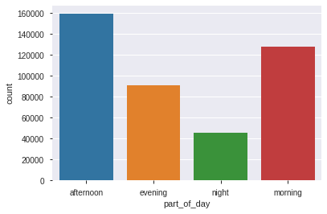

```python
# Visualize Which part of day mostly the calls are made
sns.countplot(x='part_of_day',data=df)
```

```
afternoon    37.609251
morning      30.184544
evening      21.470646
night        10.735559
Name: part_of_day, dtype: float64
```

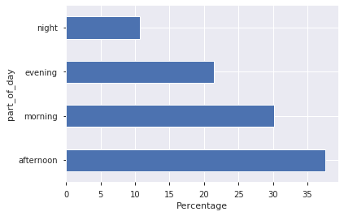

```python
print (df['part_of_day'].value_counts(normalize=True) * 100)
_, ax = plt.subplots()
ax.set_xlabel("Percentage")
ax.set_ylabel("part_of_day")
sns.set(rc={'figure.figsize': (9,8)})
(df['part_of_day'].value_counts(normalize=True) * 100).plot.barh()
```

We can see that most of the calls (i.e Around 67 % of calls) are made during Morning and afternoon time between 5 am to 5 pm

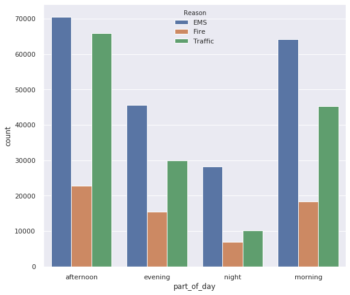

```python
sns.countplot(x='part_of_day',data=df, hue='Reason')
```

From Above graph we can notice that most of the calls are Emergency calss and Traffic calls Apart from EMS calls , Traffic calls are also higher subsequently during Morning and Afternoon.

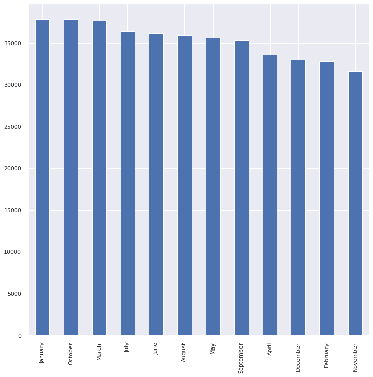

```python
df['Month'].value_counts().plot(kind='bar',figsize=(12,12))
```

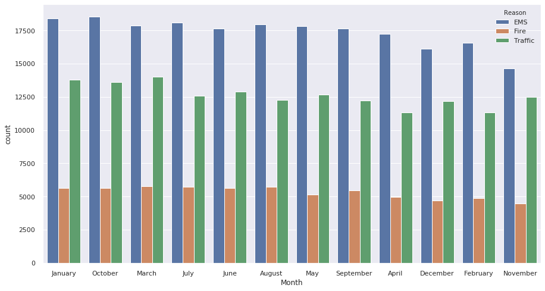

```python
plt.figure(figsize=(15,8))
sns.countplot(data=df, x='Month', order=df.Month.value_counts().index, hue='Reason')
```

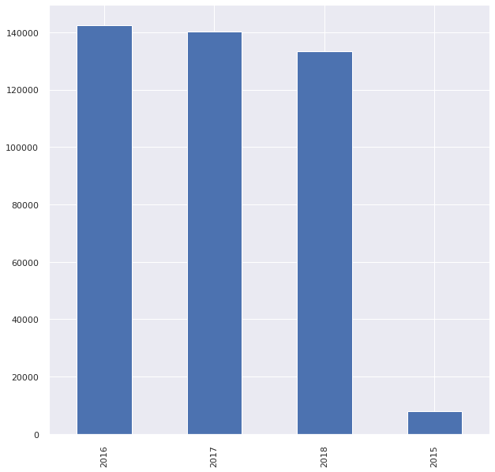

```python
df['Year'].value_counts().plot(kind='bar',figsize=(10,10))
```

From the Above two graphs we came to know that we have less data for year 2015 and more data for year 2016,2017 Also in moth of January, October and March there is a slightly more no of calls compared to other months and as expected the EMS and Traffic calls are the most in this time period

```python
# plt.figure(figsize=(15,8))
# sns.countplot(x='Month',data=df, hue='Reason')
```

```python
import folium
from folium import plugins
from io import StringIO
import matplotlib.gridspec as gridspec
```

```python
location = folium.Map([df['lat'].mean(),df['lng'].mean()], zoom_start=15,tiles='OpenStreetMap')
location
```

[interactive chart not shown]

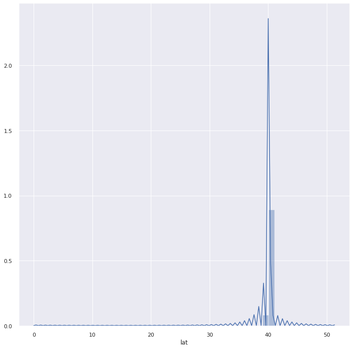

```python
sns.set(rc={'figure.figsize': (12, 12)})
sns.distplot(df['lat'],hist=True, kde=True);
```

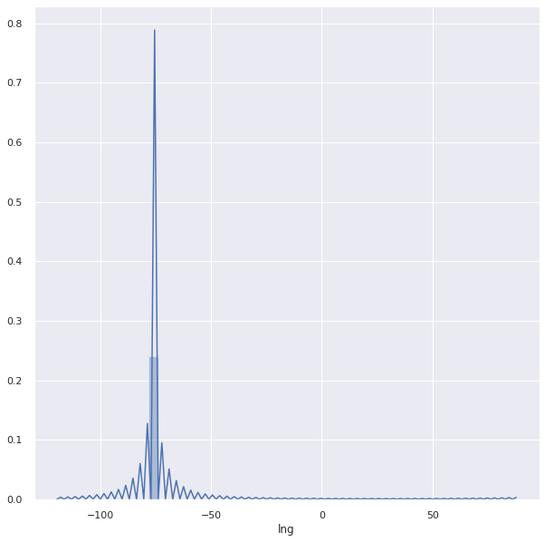

```python
sns.set(rc={'figure.figsize': (10,10)})
sns.distplot(df['lng'],hist=True, kde=True);
```

```
<BarContainer object of 15 artists>
```

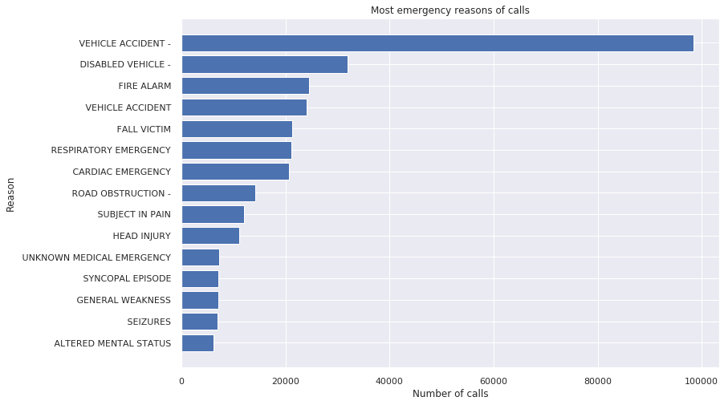

```python
# We shall find out the maximum calls made for any reason

Calls_made = df['Reason_subtype'].value_counts()[:15]
plt.figure(figsize=(12, 8))
x = list(Calls_made.index)
y = list(Calls_made.values)
x.reverse()
y.reverse()

plt.title("Most emergency reasons of calls")
plt.ylabel("Reason")
plt.xlabel("Number of calls")

plt.barh(x, y)
```

Clearly due to Vehicle Accident most of the 911 calls were made followed by Disabled Vehicle and low were for Head Injuries , general weakness etc

Also We can notice that since most of the calls were of EMS and Traffic, so Vehicle Accident should fall under both Head reason i.e EMS and Traffic

```python
Calls_per_daytiming = df.groupby(by=['Reason','part_of_day']).count()['Reason_subtype'].unstack().reset_index()
Calls_per_daytiming
```

| part_of_day | Reason | afternoon | evening | morning | night |
| --- | --- | --- | --- | --- | --- |
| 0 | EMS | 70579 | 45579 | 64224 | 28294 |
| 1 | Fire | 22881 | 15496 | 18414 | 6984 |
| 2 | Traffic | 65969 | 29941 | 45317 | 10231 |

```python
dayHour = df.groupby(by=['day name','part_of_day']).count()['Reason_subtype'].unstack()
dayHour.head()
```

| part_of_day day name | afternoon | evening | morning | night |
| --- | --- | --- | --- | --- |
| Friday | 25745 | 14314 | 19057 | 6635 |
| Monday | 22911 | 12454 | 19977 | 5976 |
| Saturday | 20453 | 13347 | 15379 | 7914 |
| Sunday | 17512 | 11496 | 13545 | 7571 |
| Thursday | 24335 | 13094 | 19777 | 5953 |

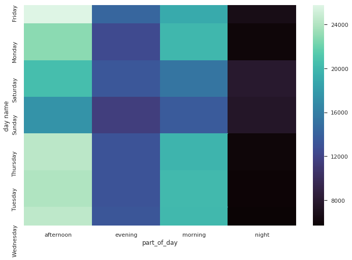

```python
# Visualize through Heatmap
plt.figure(figsize=(12, 8))
sns.heatmap(dayHour,cmap='mako')
```

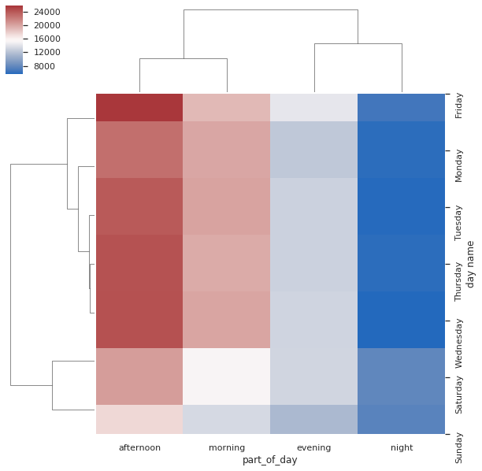

```python
plt.figure(figsize=(12, 8))
sns.clustermap(dayHour, cmap='vlag')
```

We notice that for Sunday's we have least calls But as compared to Monday to Thursday nights Friday, Saturday ,Sunday night calls are subsequently higher

```python
# Filtering the EMS calls and its Reason Types
filtered_EMS_calls = df[(df['Reason']!='Fire') & (df['Reason']!='Traffic')]['Reason_subtype']
filtered_EMS_calls
```

```
0            BACK PAINS/INJURY
1           DIABETIC EMERGENCY
3            CARDIAC EMERGENCY
4                    DIZZINESS
5                  HEAD INJURY
                  ...
423883         SUBJECT IN PAIN
423887                SEIZURES
423894             FALL VICTIM
423895        SYNCOPAL EPISODE
423901     MEDICAL ALERT ALARM
Name: Reason_subtype, Length: 208676, dtype: object
```

```
 FALL VICTIM              10.184688
 RESPIRATORY EMERGENCY    10.139163
 CARDIAC EMERGENCY         9.879430
 VEHICLE ACCIDENT          8.112097
 SUBJECT IN PAIN           5.751021
                            ...
 HIT + RUN                 0.000479
 VEHICLE LEAKING FUEL      0.000479
 PUBLIC SERVICE            0.000479
 DISABLED VEHICLE          0.000479
 POLICE INFORMATION        0.000479
Name: Reason_subtype, Length: 80, dtype: float64
```

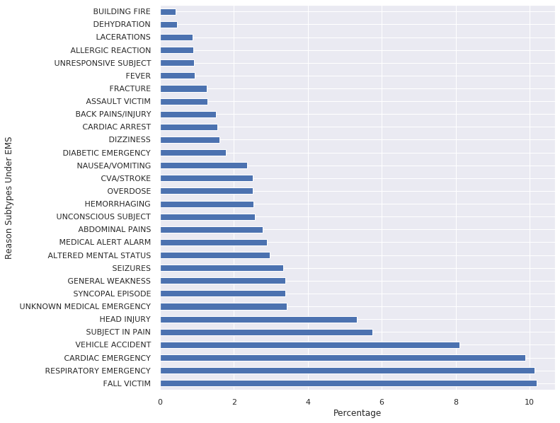

```python
# Visualising the top 30 Reason among EMS category
print (filtered_EMS_calls.value_counts(normalize=True) * 100)
_, ax = plt.subplots()
ax.set_xlabel("Percentage")
ax.set_ylabel("Reason Subtypes Under EMS")
sns.set(rc={'figure.figsize': (9,8)})
(filtered_EMS_calls.value_counts(normalize=True) * 100)[:30].plot(kind='barh',figsize=(10,10))
```

There is drastic fall in no of calls from Fever, dehydration and building fire and so on .

```python
#Filtering Traffic calls and its sub categories
filtered_traffic = df[(df['Reason']!='EMS') & (df['Reason']!='Fire')]['Reason_subtype']
filtered_traffic
```

```
9          VEHICLE ACCIDENT -
10         VEHICLE ACCIDENT -
11         VEHICLE ACCIDENT -
12         VEHICLE ACCIDENT -
13         VEHICLE ACCIDENT -
                 ...
423904     VEHICLE ACCIDENT -
423905     VEHICLE ACCIDENT -
423906     VEHICLE ACCIDENT -
423907     VEHICLE ACCIDENT -
423908     DISABLED VEHICLE -
Name: Reason_subtype, Length: 151458, dtype: object
```

```
 VEHICLE ACCIDENT -             64.969166
 DISABLED VEHICLE -             21.042797
 ROAD OBSTRUCTION -              9.331960
 HAZARDOUS ROAD CONDITIONS -     2.901795
 VEHICLE FIRE -                  1.509329
 VEHICLE LEAKING FUEL -          0.153178
 DEBRIS/FLUIDS ON HIGHWAY -      0.091775
Name: Reason_subtype, dtype: float64
```

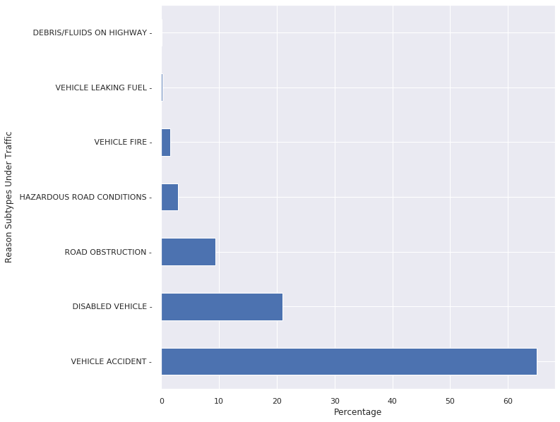

```python
# Visualising the top reasons among Traffic category
print (filtered_traffic.value_counts(normalize=True) * 100)
_, ax = plt.subplots()
ax.set_xlabel("Percentage")
ax.set_ylabel("Reason Subtypes Under Traffic")
sns.set(rc={'figure.figsize': (9,8)})
(filtered_traffic.value_counts(normalize=True) * 100)[:30].plot(kind='barh',figsize=(10,10))
```

So from the above graph its clear that Vehicle Accident calls falls under both EMS and Traffic and it comprises of 65% under Traffic category .

There is very few calls for reason hazardous Road condition or Vehicle Fire

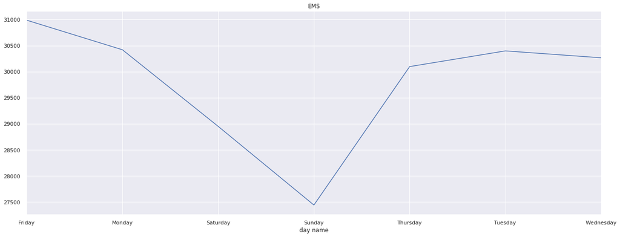

```python
plt.figure(figsize=(18,7))
df[df['Reason']=='EMS'].groupby('day name').count()['twp'].plot()
plt.title('EMS')
plt.tight_layout()
```

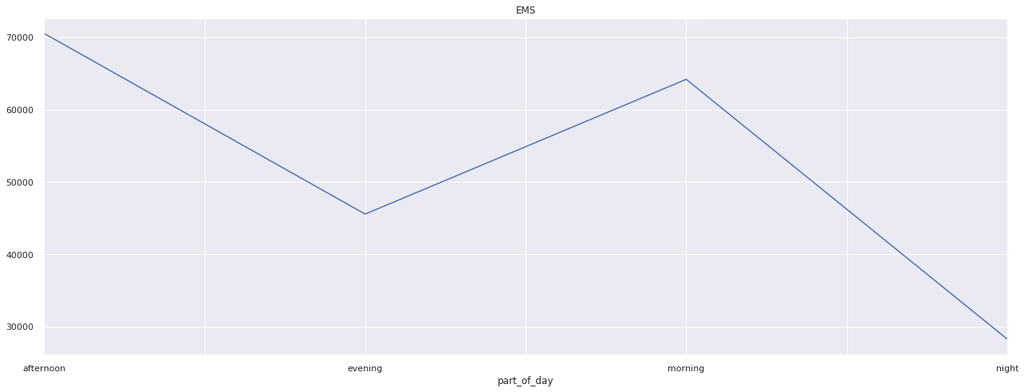

```python
plt.figure(figsize=(18,7))
df[df['Reason']=='EMS'].groupby('part_of_day').count()['twp'].plot()
plt.title('EMS')
plt.tight_layout()
```

```python
#As mentioned above,
#Morning and Afternoon time are the highest no of calls made which is clear through the above line plot
```

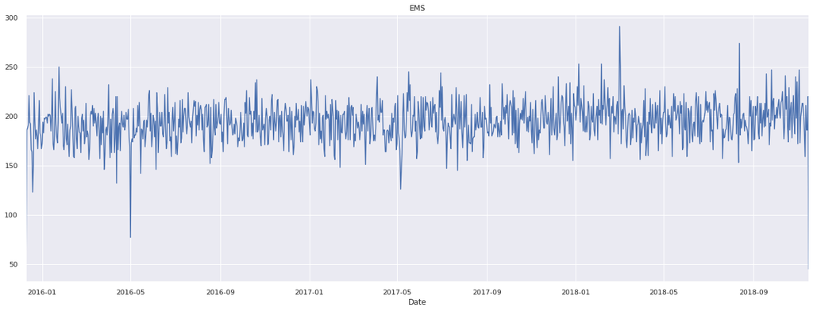

```python
plt.figure(figsize=(18,7))
df[df['Reason']=='EMS'].groupby('Date').count()['twp'].plot()
plt.title('EMS')
plt.tight_layout()
```

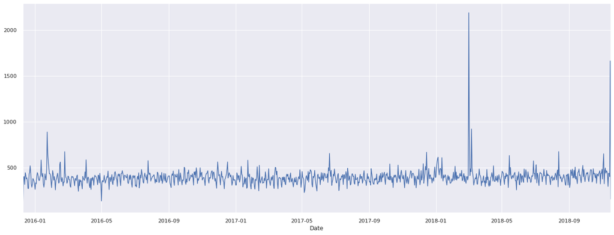

```python
plt.figure(figsize=(18,7))
df.groupby('Date').count()['twp'].plot()
plt.tight_layout()
```

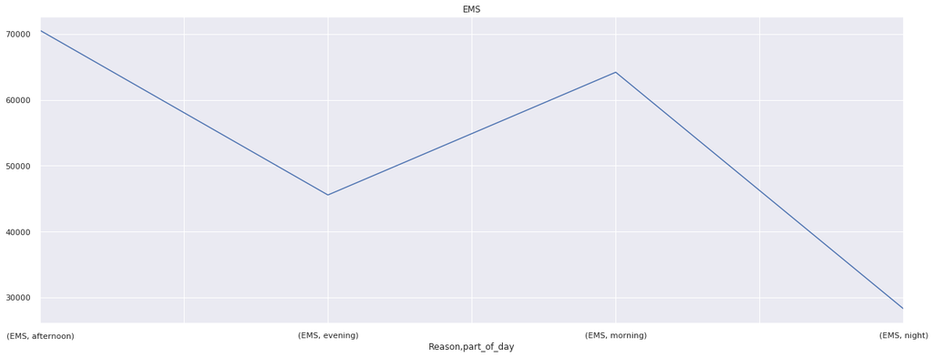

```python
plt.figure(figsize=(18,7))
df[df['Reason']=='EMS'].groupby(by=['Reason','part_of_day']).count()['twp'].plot()
plt.title('EMS')
plt.tight_layout()
```

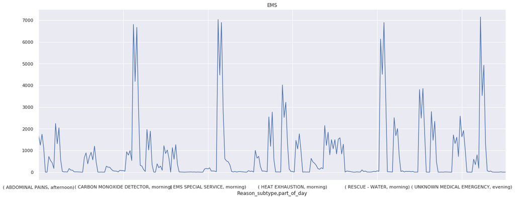

```python
plt.figure(figsize=(18,7))
df[df['Reason']=='EMS'].groupby(by=['Reason_subtype','part_of_day']).count()['twp'].plot()
plt.title('EMS')
plt.tight_layout()
```

We can see how the data is spreaded from the above line graphs. In Month of March we can see high peaks in no of calls specially in Year 2018

```python
dayMonth = df.groupby(by=['day name','Month']).count()['Reason'].unstack()
dayMonth.head()
```

| Month day name | April | August | December | February | January | July | June | March | May | November | October | September |
| --- | --- | --- | --- | --- | --- | --- | --- | --- | --- | --- | --- | --- |
| Friday | 5195 | 5312 | 5570 | 4848 | 5532 | 5380 | 5867 | 7344 | 4989 | 4525 | 5179 | 6010 |
| Monday | 5154 | 5212 | 4286 | 5214 | 5716 | 5792 | 5045 | 4663 | 5019 | 4157 | 6385 | 4675 |
| Saturday | 4947 | 4355 | 5200 | 4431 | 5103 | 4883 | 4868 | 4914 | 4275 | 4043 | 5051 | 5023 |
| Sunday | 4628 | 3963 | 3896 | 3806 | 4882 | 5114 | 4019 | 3569 | 3940 | 3210 | 4852 | 4245 |
| Thursday | 4637 | 5328 | 4899 | 4708 | 4985 | 4954 | 5951 | 6010 | 5469 | 5978 | 4940 | 5300 |

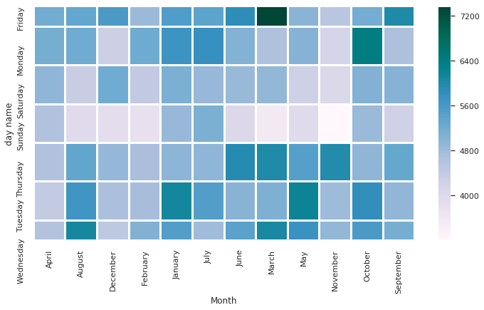

```python
#Now create a HeatMap using this new DataFrame.
plt.figure(figsize=(12,6))
sns.heatmap(dayMonth,cmap='PuBuGn',linewidths=2)
```

From the above heatmap it is clear that Month of March has high no of calls and that too Friday records the most no of calls

```python
# Finding the Unique Townships in the dataset
df[["twp","Reason"]].groupby('twp').count().sort_values("Reason")

Unique_Town = df.twp.unique()
townarray = []
corresponding_reason = []
for town in Unique_Town:
        town_len =  len(df[df["twp"] == town])
        townarray.append(town_len)
```

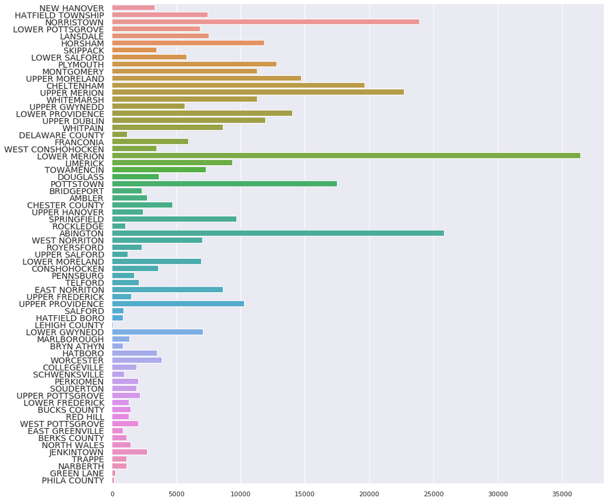

```python
# Let Us visualize which town has highest no of calls and which has least
f, ax = plt.subplots(figsize=(15, 15))
ax.set_yticklabels(Unique_Town, rotation='horizontal', fontsize='large')
g = sns.barplot(y = Unique_Town,x=townarray)
plt.show()
```

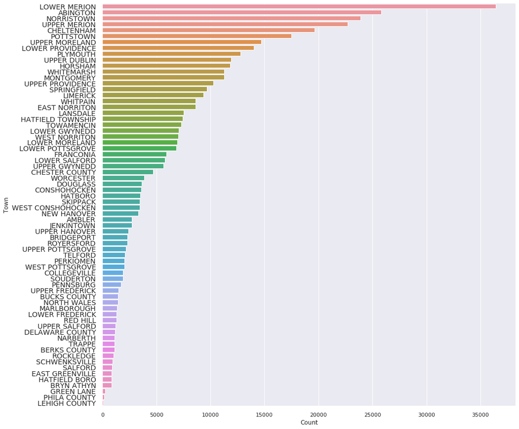

```python
# Let us see the above visualization in a sorted manner
tdf = pd.DataFrame(
    {'Town': Unique_Town,
     'Count' : townarray,
     })

tdf_sort = tdf.sort_values("Count", ascending=False).reset_index(drop=True)

f, ax = plt.subplots(figsize=(15, 15))
ax.set_yticklabels(tdf.Town, rotation='horizontal', fontsize='large')
g = sns.barplot(y = tdf_sort.Town, x= tdf_sort.Count)
plt.show()
```

We can notice that Lower Merion has highest no of 911 calls received followed by Abington and Norristown.

Least calls were received from Phila County and Lehigh County

```python
# Finding out the EMS reason of call made for the unique towns
for town in Unique_Town:
    EMS = df[(df['Reason']!='Fire') & (df['Reason']!='Traffic')][["twp","Reason"]]
```

```
NORRISTOWN          15588
LOWER MERION        13841
ABINGTON            13049
POTTSTOWN           11086
LOWER PROVIDENCE     8924
CHELTENHAM           8895
UPPER MERION         8734
UPPER MORELAND       7508
HORSHAM              5301
PLYMOUTH             5246
SPRINGFIELD          5039
EAST NORRITON        5007
MONTGOMERY           4672
WHITEMARSH           4645
UPPER DUBLIN         4641
Name: twp, dtype: int64
```

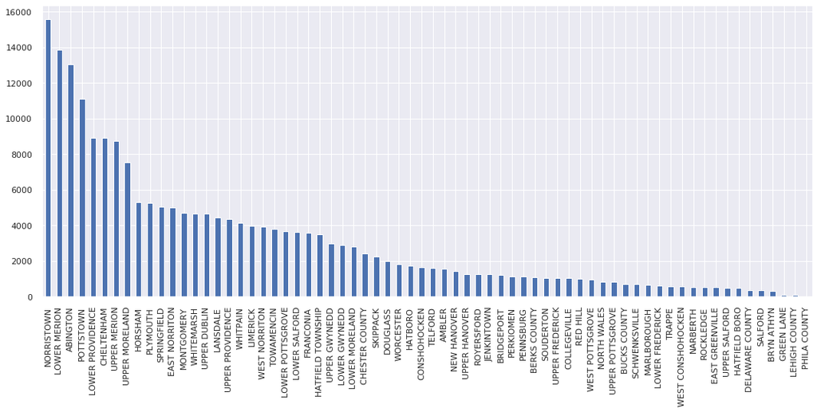

```python
print (EMS.twp.value_counts()[0:15])
plt.figure(figsize=(18,7))
EMS.twp.value_counts().plot.bar()
```

We can notice from above bar chart that Norristown and Lower Merion have received highest no of 911 calls And Green Lane , Lehigh County and Phila County received the least calls.

Note: These all calls were categorized under EMS reason

Let us see for one more reason , say under Traffic reason which townships receive more calls

```
LOWER MERION        16135
UPPER MERION        11176
ABINGTON             8732
CHELTENHAM           7637
PLYMOUTH             5955
UPPER DUBLIN         5742
UPPER MORELAND       5496
MONTGOMERY           5206
HORSHAM              5012
NORRISTOWN           4970
WHITEMARSH           4759
UPPER PROVIDENCE     4142
LOWER PROVIDENCE     3791
LIMERICK             3610
POTTSTOWN            3455
Name: twp, dtype: int64
```

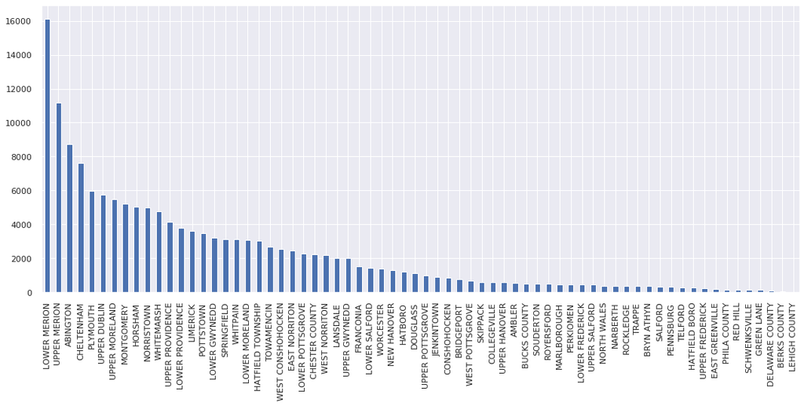

```python
# Finding out the Traffic reason of call made for the unique towns
for town in Unique_Town:
    Traffic = df[(df['Reason']!='Fire') & (df['Reason']!='EMS')][["twp","Reason"]]


print (Traffic.twp.value_counts()[0:15])
plt.figure(figsize=(18,7))
Traffic.twp.value_counts().plot.bar()
```

We can clearly note the difference in Calls reason in different Townships.

From the above chart it is clear that Lower Merion received high no of 911 calls for Traffic reason followed by Upper Merion and NORRISTOWN has significantly low no of calls for traffic reason.

Least was observed in Lehigh County.

Now Since Under traffic reason we had maximum calls due to Vehicle Accident, so we can assume that Lower Merion is an Accident prone region , since we observed most of the Traffic calls made from Lower Merion.

Also let us see the same for Fire reason.

```
LOWER MERION        6465
ABINGTON            4054
NORRISTOWN          3325
CHELTENHAM          3097
POTTSTOWN           2959
UPPER MERION        2784
WHITEMARSH          1878
UPPER PROVIDENCE    1809
LIMERICK            1764
UPPER MORELAND      1703
PLYMOUTH            1599
UPPER DUBLIN        1527
HORSHAM             1506
SPRINGFIELD         1498
MONTGOMERY          1398
Name: twp, dtype: int64
```

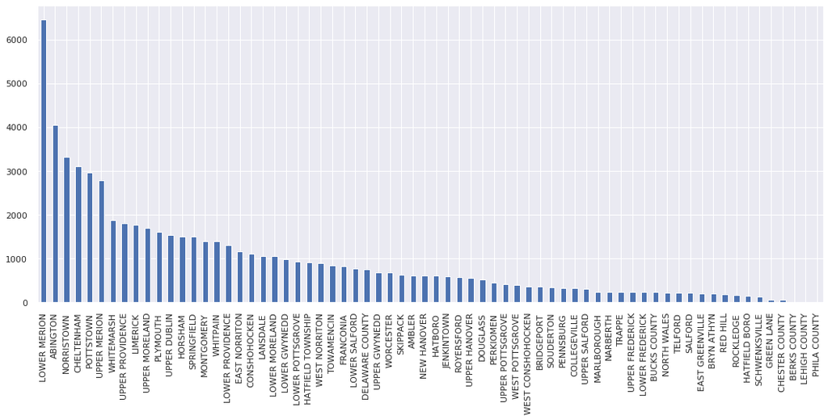

```python
# Finding out the Fire reason of call made for the unique towns
for town in Unique_Town:
    Fire = df[(df['Reason']!='Traffic') & (df['Reason']!='EMS')][["twp","Reason"]]


print (Fire.twp.value_counts()[0:15])
plt.figure(figsize=(18,7))
Fire.twp.value_counts().plot.bar()
```

We can also see that Lower Merion has higher frequency of calls Fire reason too followed by Abington.

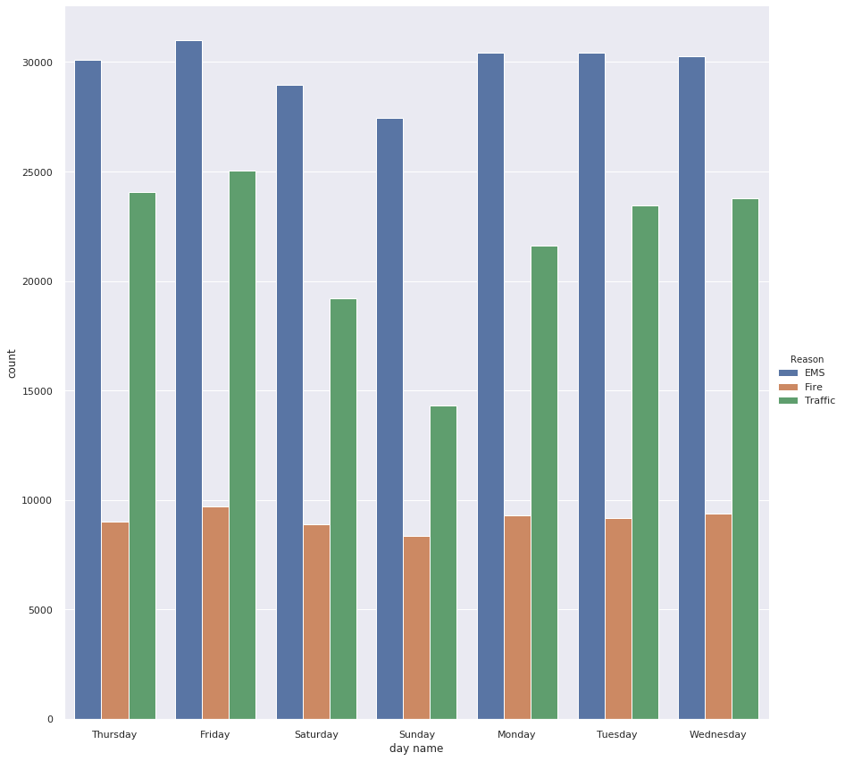

```python
sns.catplot(x="day name", hue="Reason",

                data=df, kind="count",

                height=12, aspect=1);
```

Quick Overview of what key insights we got from the above analysis:

1. Most No of calls were due to EMS Reason followed by Traffic
2. Lower Merion region received high calls due to Traffic, which tends that it might be an accident prone region
3. Norristown received the highest no of Emergency calls
4. Calls were mostly done in weekdays and during morning and afternoon time
5. On Sunday it was seen that the calls made were least but Weekend night calls were subsequently higher than weekdays nigh calls
6. In the Month of March and January we observed the most of the calls were received